# Peer-graded Assignment: Prediction Assignment Writeup

# 1. Introduction

This is the final assignment for the Practical Machine Learning Course, part of the John Hopkins Data Science Specialization. One thing that people regularly do is quantify how much of a particular activity they do, but they rarely quantify how well they do it. In this project, the goal will be to use data from accelerometers on the belt, forearm, arm, and dumbell of 6 participants. They were asked to perform barbell lifts correctly and incorrectly in 5 different ways. More information is available from the website here: http://web.archive.org/web/20161224072740/http:/groupware.les.inf.puc-rio.br/har (see the section on the Weight Lifting Exercise Dataset). We want to predict the manner in which they did the exercise. This is the “classe” variable in the training set. Using devices such as Jawbone Up, Nike FuelBand, and Fitbit it is now possible to collect a large amount of data about personal activity relatively inexpensively. These type of devices are part of the quantified self movement – a group of enthusiasts who take measurements about themselves regularly to improve their health, to find patterns in their behavior, or because they are tech geeks.

Before starting I would like to thank “http://web.archive.org/web/20161224072740/http:/groupware.les.inf.puc-rio.br/har” as they have been very generous in allowing their data to be used for this kind of assignment.

# 2. Data loading and cleaning

First, we load the necessary libraries. Then we download the data. The data are split into training (**datatrain**) and testing (**datatest**) data.

```r
library(knitr)
library(caret)
```

```r
library(rpart)
library(rpart.plot)
library(randomForest)
library(rattle)
datatrain <- read.csv(url("http://d396qusza40orc.cloudfront.net/predmachlearn/pml-training.csv"))
datatest <- read.csv(url("http://d396qusza40orc.cloudfront.net/predmachlearn/pml-testing.csv"))
```

We have to clean the datatrain data: eliminate the near zero variance features, remove the columns with missing values and the first 6 features because are useless for our purposes.

```r
nzv <- nearZeroVar(datatrain)
datatrain2 <- (datatrain[,-nzv])
datatrain3 <- (datatrain2[,colSums(is.na(datatrain2))==0])
datatrain4 <- datatrain3[,-(1:6)]
names(datatrain4)
```

```
##  [1] "roll_belt"            "pitch_belt"           "yaw_belt"
##  [4] "total_accel_belt"     "gyros_belt_x"         "gyros_belt_y"
##  [7] "gyros_belt_z"         "accel_belt_x"         "accel_belt_y"
## [10] "accel_belt_z"         "magnet_belt_x"        "magnet_belt_y"
## [13] "magnet_belt_z"        "roll_arm"             "pitch_arm"
## [16] "yaw_arm"              "total_accel_arm"      "gyros_arm_x"
## [19] "gyros_arm_y"          "gyros_arm_z"          "accel_arm_x"
## [22] "accel_arm_y"          "accel_arm_z"          "magnet_arm_x"
## [25] "magnet_arm_y"         "magnet_arm_z"         "roll_dumbbell"
## [28] "pitch_dumbbell"       "yaw_dumbbell"         "total_accel_dumbbell"
## [31] "gyros_dumbbell_x"     "gyros_dumbbell_y"     "gyros_dumbbell_z"
## [34] "accel_dumbbell_x"     "accel_dumbbell_y"     "accel_dumbbell_z"
## [37] "magnet_dumbbell_x"    "magnet_dumbbell_y"    "magnet_dumbbell_z"
## [40] "roll_forearm"         "pitch_forearm"        "yaw_forearm"
## [43] "total_accel_forearm"  "gyros_forearm_x"      "gyros_forearm_y"
## [46] "gyros_forearm_z"      "accel_forearm_x"      "accel_forearm_y"
## [49] "accel_forearm_z"      "magnet_forearm_x"     "magnet_forearm_y"
## [52] "magnet_forearm_z"     "classe"
```

```r
# nzv2 <- nearZeroVar(datatest)
# datatest2 <- (datatest[,-nzv])
# datatest3 <- (datatest2[,colSums(is.na(datatest2))==0])
# datatest4 <- datatest3[,-(1:6)]
# names(datatest4)
```

# 3. Prediction models

```r
set.seed(12345)
inTrain <- createDataPartition(datatrain4$classe, p=0.75, list=FALSE)

training <- datatrain4[inTrain,]
dim(training)
```

```
## [1] 14718    53
```

```r
head(training)
```

```
##   roll_belt pitch_belt yaw_belt total_accel_belt gyros_belt_x gyros_belt_y
## 2      1.41       8.07    -94.4                3         0.02         0.00
## 3      1.42       8.07    -94.4                3         0.00         0.00
## 4      1.48       8.05    -94.4                3         0.02         0.00
## 5      1.48       8.07    -94.4                3         0.02         0.02
## 6      1.45       8.06    -94.4                3         0.02         0.00
## 7      1.42       8.09    -94.4                3         0.02         0.00
##   gyros_belt_z accel_belt_x accel_belt_y accel_belt_z magnet_belt_x
## 2        -0.02          -22            4           22            -7
## 3        -0.02          -20            5           23            -2
## 4        -0.03          -22            3           21            -6
## 5        -0.02          -21            2           24            -6
## 6        -0.02          -21            4           21             0
## 7        -0.02          -22            3           21            -4
##   magnet_belt_y magnet_belt_z roll_arm pitch_arm yaw_arm total_accel_arm
```

[output cut: 69 more lines]

```r
testing <- datatrain4[-inTrain,]
dim(testing)
```

```
## [1] 4904   53
```

```r
head(testing)
```

```
##    roll_belt pitch_belt yaw_belt total_accel_belt gyros_belt_x
## 1       1.41       8.07    -94.4                3         0.00
## 9       1.43       8.16    -94.4                3         0.02
## 10      1.45       8.17    -94.4                3         0.03
## 15      1.45       8.20    -94.4                3         0.00
## 19      1.57       8.06    -94.4                3         0.00
## 21      1.60       8.10    -94.4                3         0.02
##    gyros_belt_y gyros_belt_z accel_belt_x accel_belt_y accel_belt_z
## 1             0        -0.02          -21            4           22
## 9             0        -0.02          -20            2           24
## 10            0         0.00          -21            4           22
## 15            0         0.00          -21            2           22
## 19            0        -0.02          -20            5           21
## 21            0        -0.02          -20            1           20
##    magnet_belt_x magnet_belt_y magnet_belt_z roll_arm pitch_arm yaw_arm
```

[output cut: 69 more lines]

We will use two methods to model the training data and to predict with the testing data. The fist one will be the **random forests**. A confusion matrix is shown to better visualize the accuracy of the model.

```r
set.seed(11111)
randforest <- train(classe ~ ., training, method = "rf", trControl = trainControl(method = "cv"))
randforest$finalModel
```

```
##
## Call:
##  randomForest(x = x, y = y, mtry = param$mtry)
##                Type of random forest: classification
##                      Number of trees: 500
## No. of variables tried at each split: 27
##
##         OOB estimate of  error rate: 0.63%
## Confusion matrix:
##      A    B    C    D    E class.error
## A 4179    4    2    0    0 0.001433692
## B   17 2827    3    1    0 0.007373596
## C    0   11 2547    9    0 0.007791196
## D    0    1   29 2378    4 0.014096186
## E    0    0    3    8 2695 0.004065041
```

```r
predictrandforest <- predict(randforest, testing)
confmatrandforest <- confusionMatrix(predictrandforest, testing$classe)
confmatrandforest
```

```
## Confusion Matrix and Statistics
##
##           Reference
## Prediction    A    B    C    D    E
##          A 1393    6    0    0    0
##          B    2  938    3    0    0
##          C    0    5  848   10    2
##          D    0    0    4  794    5
##          E    0    0    0    0  894
##
## Overall Statistics
##
##                Accuracy : 0.9925
##                  95% CI : (0.9896, 0.9947)
##     No Information Rate : 0.2845
##     P-Value [Acc > NIR] : < 2.2e-16
##
##                   Kappa : 0.9905
##  Mcnemar's Test P-Value : NA
##
## Statistics by Class:
##
##                      Class: A Class: B Class: C Class: D Class: E
## Sensitivity            0.9986   0.9884   0.9918   0.9876   0.9922
## Specificity            0.9983   0.9987   0.9958   0.9978   1.0000
## Pos Pred Value         0.9957   0.9947   0.9803   0.9888   1.0000
## Neg Pred Value         0.9994   0.9972   0.9983   0.9976   0.9983
## Prevalence             0.2845   0.1935   0.1743   0.1639   0.1837
## Detection Rate         0.2841   0.1913   0.1729   0.1619   0.1823
## Detection Prevalence   0.2853   0.1923   0.1764   0.1637   0.1823
## Balanced Accuracy      0.9984   0.9936   0.9938   0.9927   0.9961
```

The second will be the **decision trees**. A confusion matrix is shown to better visualize the accuracy of the model.

```r
set.seed(22222)
decisiontree <- rpart(classe ~ ., training, method = "class")
decisiontree
```

```
## n= 14718
##
## node), split, n, loss, yval, (yprob)
##       * denotes terminal node
##
##    1) root 14718 10533 A (0.28 0.19 0.17 0.16 0.18)
##      2) roll_belt< 130.5 13467  9291 A (0.31 0.21 0.19 0.18 0.11)
##        4) pitch_forearm< -33.95 1175     8 A (0.99 0.0068 0 0 0) *
##        5) pitch_forearm>=-33.95 12292  9283 A (0.24 0.23 0.21 0.2 0.12)
##         10) yaw_belt>=169.5 606    59 A (0.9 0.046 0 0.045 0.0066) *
##         11) yaw_belt< 169.5 11686  8874 B (0.21 0.24 0.22 0.2 0.12)
##           22) magnet_dumbbell_z< -88.5 1493   638 A (0.57 0.28 0.046 0.076 0.023)
##             44) magnet_dumbbell_y>=-565.5 1124   272 A (0.76 0.18 0.012 0.025 0.02) *
##             45) magnet_dumbbell_y< -565.5 369   155 B (0.0081 0.58 0.15 0.23 0.03) *
##           23) magnet_dumbbell_z>=-88.5 10193  7695 C (0.16 0.23 0.25 0.22 0.14)
##             46) pitch_belt< -42.95 606   102 B (0.017 0.83 0.097 0.028 0.026) *
##             47) pitch_belt>=-42.95 9587  7148 C (0.17 0.2 0.25 0.24 0.15)
##               94) magnet_dumbbell_x>=-447.5 4142  2886 B (0.17 0.3 0.097 0.24 0.19)
##                188) roll_belt< 117.5 2562  1439 B (0.17 0.44 0.023 0.12 0.25)
##                  376) magnet_dumbbell_z< 18.5 633    81 B (0.088 0.87 0.0016 0.017 0.021) *
##                  377) magnet_dumbbell_z>=18.5 1929  1303 E (0.19 0.3 0.031 0.16 0.32)
##                    754) total_accel_dumbbell< 5.5 401    92 A (0.77 0.11 0.025 0.087 0.0025) *
##                    755) total_accel_dumbbell>=5.5 1528   903 E (0.038 0.34 0.032 0.18 0.41)
##                     1510) roll_dumbbell< 39.39063 314    42 B (0.025 0.87 0.0032 0.041 0.064) *
##                     1511) roll_dumbbell>=39.39063 1214   609 E (0.041 0.21 0.04 0.21 0.5) *
##                189) roll_belt>=117.5 1580   906 D (0.18 0.084 0.22 0.43 0.095)
##                  378) roll_belt>=122.5 569   311 A (0.45 0.098 0.18 0.016 0.25)
##                    756) yaw_belt< 4.24 406   148 A (0.64 0.14 0.2 0.022 0.0099) *
##                    757) yaw_belt>=4.24 163    24 E (0 0.0061 0.14 0 0.85) *
##                  379) roll_belt< 122.5 1011   346 D (0.023 0.076 0.24 0.66 0.0069) *
##               95) magnet_dumbbell_x< -447.5 5445  3408 C (0.16 0.12 0.37 0.23 0.11)
##                190) yaw_arm< -119.5 261     5 A (0.98 0.019 0 0 0) *
##                191) yaw_arm>=-119.5 5184  3147 C (0.12 0.12 0.39 0.24 0.12)
##                  382) accel_dumbbell_y< -19.5 1087   307 C (0.029 0.14 0.72 0.041 0.069) *
##                  383) accel_dumbbell_y>=-19.5 4097  2840 C (0.15 0.11 0.31 0.3 0.13)
##                    766) magnet_dumbbell_z< 19.5 1448   887 A (0.39 0.15 0.068 0.3 0.099)
##                     1532) accel_dumbbell_x< -48.5 393    60 A (0.85 0.048 0.018 0.046 0.041) *
##                     1533) accel_dumbbell_x>=-48.5 1055   643 D (0.22 0.19 0.086 0.39 0.12)
##                       3066) yaw_belt>=-93.25 578   389 B (0.21 0.33 0.14 0.13 0.2) *
##                       3067) yaw_belt< -93.25 477   141 D (0.22 0.015 0.025 0.7 0.031) *
##                    767) magnet_dumbbell_z>=19.5 2649  1490 C (0.017 0.096 0.44 0.3 0.15)
##                     1534) roll_belt>=125.5 420    47 C (0.067 0.033 0.89 0.012 0) *
##                     1535) roll_belt< 125.5 2229  1443 C (0.0076 0.11 0.35 0.35 0.18)
##                       3070) yaw_belt< -87.55 1229   607 C (0.0081 0.18 0.51 0.14 0.17) *
##                       3071) yaw_belt>=-87.55 1000   387 D (0.007 0.024 0.16 0.61 0.19) *
##      3) roll_belt>=130.5 1251     9 E (0.0072 0 0 0 0.99) *
```

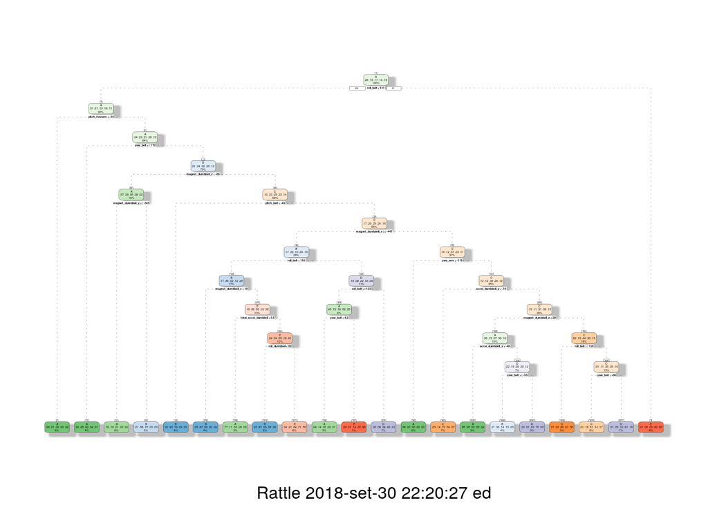

```r
fancyRpartPlot(decisiontree)
```

```r
predictdectree <- predict(decisiontree, testing, type = "class")
decisiontreecmatrix <- confusionMatrix(predictdectree, testing$classe)
decisiontreecmatrix
```

```
## Confusion Matrix and Statistics
##
##           Reference
## Prediction    A    B    C    D    E
##          A 1260  156   33   40   23
##          B   52  555   73   52   52
##          C   24  136  575   83   95
##          D   40   33  150  513   89
##          E   19   69   24  116  642
##
## Overall Statistics
##
##                Accuracy : 0.7229
##                  95% CI : (0.7101, 0.7354)
##     No Information Rate : 0.2845
##     P-Value [Acc > NIR] : < 2.2e-16
##
##                   Kappa : 0.6486
##  Mcnemar's Test P-Value : < 2.2e-16
##
## Statistics by Class:
##
##                      Class: A Class: B Class: C Class: D Class: E
## Sensitivity            0.9032   0.5848   0.6725   0.6381   0.7125
## Specificity            0.9282   0.9421   0.9165   0.9239   0.9430
## Pos Pred Value         0.8333   0.7079   0.6298   0.6218   0.7379
## Neg Pred Value         0.9602   0.9044   0.9298   0.9287   0.9358
## Prevalence             0.2845   0.1935   0.1743   0.1639   0.1837
## Detection Rate         0.2569   0.1132   0.1173   0.1046   0.1309
## Detection Prevalence   0.3083   0.1599   0.1862   0.1682   0.1774
## Balanced Accuracy      0.9157   0.7635   0.7945   0.7810   0.8278
```

# 4. Conclusions

```r
predicttesting <- predict(randforest, datatest)
predicttesting
```

```
##  [1] B A B A A E D B A A B C B A E E A B B B
## Levels: A B C D E
```